# **Time Series Forecasting in R**

Feyza Yesildas

14/03/2025

# Introduction

> This project aims to explore and analyse a time series using Meta’s Prophet forecasting system in R.

## The U.S. unemployment rate dataset

The time series that I will be exploring in this project is the monthly U.S. unemployment rate in percent unemployed from January 1948 to November 2016. This dataset can be found in the astsa package in R.

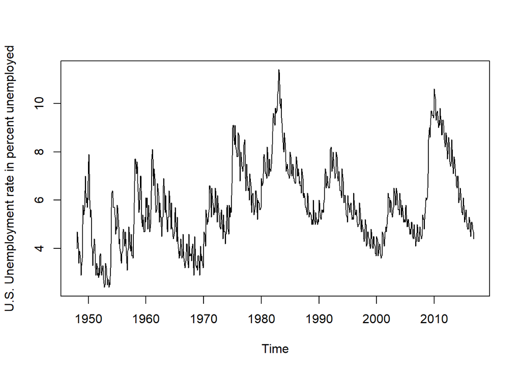

```r
#This produces a plot of the time series.
plot(astsa::UnempRate, ylab="U.S. Unemployment rate in percent unemployed")
```

# Analysing the Time Series

## 1. Decomposing the data

The *decompose* function extracts the trend, seasonality and residual error from a time series and this data can then be plotted.

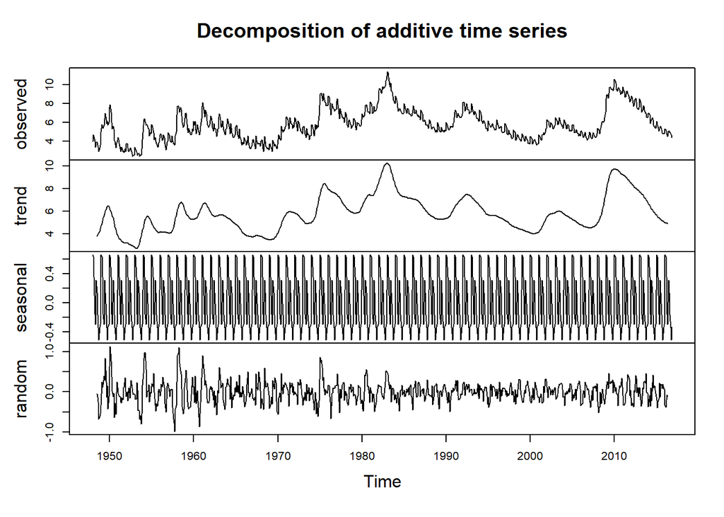

```r
plot(stats::decompose(astsa::UnempRate))
```

The observed data and trend graphs both show that the U.S. unemployment rate peaked in the early 1980s, which is in line with the early 1980s recession in the United States.

The graph showing the seasonality of this time series suggests yearly seasonality.

## 2. Average percentage growth per month in U.S. unemployment rates

It is possible to estimate the average percentage growth in the U.S. unemployment rate using linear regression.

```r
LinearModel=lm(astsa::UnempRate~time(astsa::UnempRate))
summary(LinearModel)
```

```
##
## Call:
## lm(formula = astsa::UnempRate ~ time(astsa::UnempRate))
##
## Residuals:
##     Min      1Q  Median      3Q     Max
## -2.7406 -1.2460 -0.2103  1.0490  5.5711
##
## Coefficients:
##                          Estimate Std. Error t value Pr(>|t|)
## (Intercept)            -51.338999   5.494564  -9.344   <2e-16 ***
## time(astsa::UnempRate)   0.028829   0.002772  10.402   <2e-16 ***
## ---
## Signif. codes:  0 '***' 0.001 '**' 0.01 '*' 0.05 '.' 0.1 ' ' 1
##
## Residual standard error: 1.586 on 825 degrees of freedom
## Multiple R-squared:  0.1159, Adjusted R-squared:  0.1149
## F-statistic: 108.2 on 1 and 825 DF,  p-value: < 2.2e-16
```

# Forecasting with Meta’s Prophet Forecasting System

## 1. The Prophet function

In order to forecast the data using Meta’s Prophet forecasting system, I will use the **prophet** package in R. The **prophet** package contains the *prophet* function which requires the time series data to be converted into a dataframe in R.

```r
#The data.frame() function converts the time series into a data frame.
UnempRate.df=data.frame(ds=zoo::as.yearmon(time(astsa::UnempRate)),y=astsa::UnempRate)

#The prophet function fits the data to create a model, which I have assigned to the variable ProphetModel.
ProphetModel=prophet::prophet(UnempRate.df)
```

```
## Disabling weekly seasonality. Run prophet with weekly.seasonality=TRUE to override this.
```

```
## Disabling daily seasonality. Run prophet with daily.seasonality=TRUE to override this.
```

## 2. Creating a new data frame

```r
FutureDataframe=prophet::make_future_dataframe(ProphetModel, periods=60)
```

## 3. Predicting future unemployment rates

```r
ModelPredictions = predict(ProphetModel, FutureDataframe)
```

The code below plots a graph of the prophet model against the model predictions.

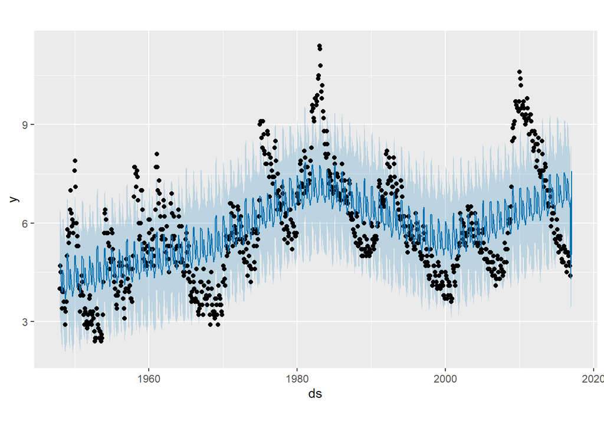

```r
plot(ProphetModel,ModelPredictions)
```

This graph shows that the predicted data, represented by the dark blue line, is not very close to the actual data and this suggests that the forecast data is not accurate.

## 4. Trend and seasonality from the forecast data

The trend and seasonality components of the time series can also be extracted from the forecast data using the *prophet_plot_components* function.

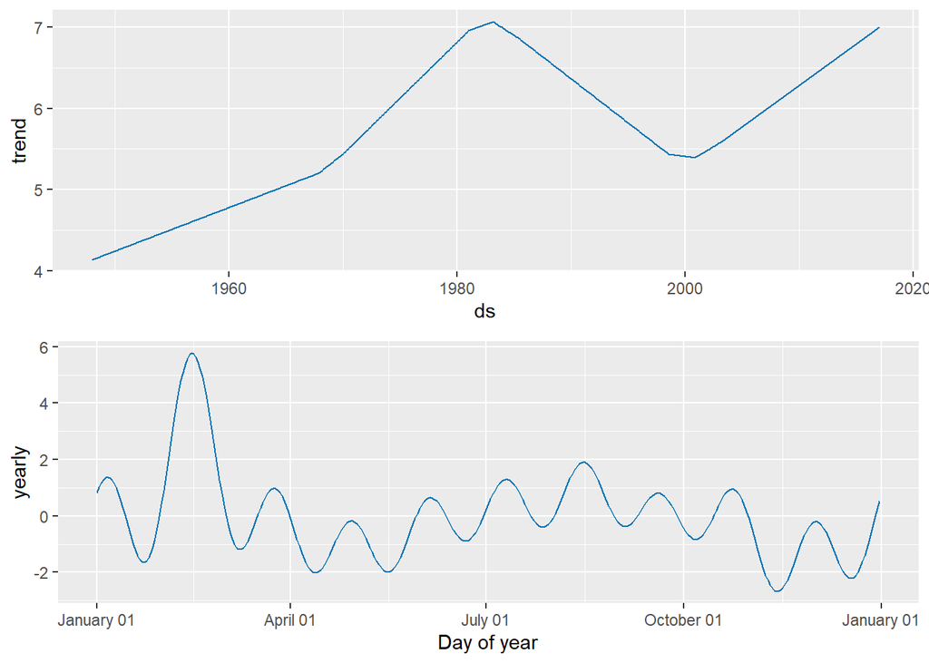

```r
prophet::prophet_plot_components(ProphetModel,ModelPredictions)
```

The trend graph shows that the rate of unemployment in the U.S. increased from 1948 to 1983 and then decreased until the early 2000s, after which it began to increase again.

The second graph, which shows the yearly seasonality, suggests that the rate of unemployment in the U.S. fluctuates throughout the year, peaks in the middle of February and falls to its lowest rate in November.